# Prediction Assigment

Marco

1-9-2020

## Prediction Assignment- Practical Machine Learning

Goal is to predict how 6 participants performed exercises as described in the “classe” variable in the training set. The best scoring machine learning algorithm found here is applied to the 20 test cases available in the test data and the predictions are submitted in appropriate format to the Course Project Prediction Quiz for automated grading.

Note: calculation of this data/markdown really takes time. Several minutes (5-10) on my 4th generation Intel I7 laptop.

## Data Loading and Exploratory Analysis

Data is coming from http://groupware.les.inf.puc-rio.br/har. This is copied from the authors website:

“Six young health participants were asked to perform one set of 10 repetitions of the Unilateral Dumbbell Biceps Curl in five different fashions: exactly according to the specification (Class A), throwing the elbows to the front (Class B), lifting the dumbbell only halfway (Class C), lowering the dumbbell only halfway (Class D) and throwing the hips to the front (Class E).”

## Data Loading and Cleaning

The training dataset is partitioned to create a Training set (70% of the data) for the modeling process and a Test set (remaining 30%) for the validations. The testing dataset is not changed and will only be used for the quiz results generation.

```r
#Download the datasets from provided URLs
Training <- "http://d396qusza40orc.cloudfront.net/predmachlearn/pml-training.csv"
Testing  <- "http://d396qusza40orc.cloudfront.net/predmachlearn/pml-testing.csv"

#Read the downloaded data files
training <- read.csv(url(Training))
testing  <- read.csv(url(Testing))

#and partition them
train_part  <- createDataPartition(training$classe, p=0.7, list=FALSE)
TrainSet <- training[train_part, ]
TestSet  <- training[-train_part, ]

# summary( training )  "this one really takes too much space, so used in running not in output
dim(training)
```

```
## [1] 19622   160
```

The training data set is made of 19622 observations on 160 columns. We noticed (summary statement) that many columns have NA or blank values on many observations. These columns are removed (90% or more empty). The first seven columns of the CSv files give information about who and when, these will also be removed from the data.

```
## [1] 13737    53
```

```
## [1] 5885   53
```

## Correlation Analysis

A correlation among variables is done before proceeding to the modeling procedures. Last column (classe) to be left out.

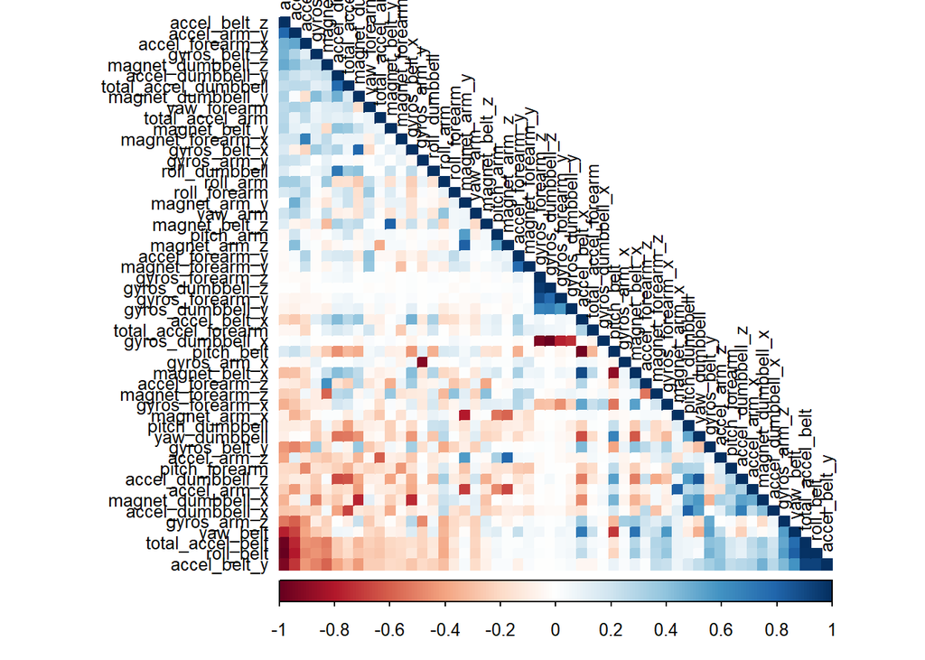

## Prediction Model Building

Three methods will be applied to model the regressions using the Train dataset and the best one with higher accuracy when applied to the Test dataset will be used for the quiz predictions. The methods are: - Random Forests - Decision Tree and - Generalized Boosted Model. A Confusion Matrix is plotted at the end of each analysis to better visualize the accuracy of the models.

### Method 1 : Random Forest

```
##
## Call:
##  randomForest(x = x, y = y, mtry = param$mtry)
##                Type of random forest: classification
##                      Number of trees: 500
## No. of variables tried at each split: 2
##
##         OOB estimate of  error rate: 0.72%
## Confusion matrix:
##      A    B    C    D    E class.error
## A 3902    3    0    0    1 0.001024066
## B   20 2632    6    0    0 0.009781791
## C    0   20 2373    3    0 0.009599332
## D    0    0   39 2212    1 0.017761989
## E    0    0    0    6 2519 0.002376238
```

```
## Confusion Matrix and Statistics
##
##           Reference
## Prediction    A    B    C    D    E
##          A 1672    7    0    0    0
##          B    2 1126    3    0    0
##          C    0    6 1023   24    1
##          D    0    0    0  939    3
##          E    0    0    0    1 1078
##
## Overall Statistics
##
##                Accuracy : 0.992
##                  95% CI : (0.9894, 0.9941)
##     No Information Rate : 0.2845
##     P-Value [Acc > NIR] : < 2.2e-16
##
##                   Kappa : 0.9899
##
##  Mcnemar's Test P-Value : NA
##
## Statistics by Class:
##
##                      Class: A Class: B Class: C Class: D Class: E
## Sensitivity            0.9988   0.9886   0.9971   0.9741   0.9963
## Specificity            0.9983   0.9989   0.9936   0.9994   0.9998
## Pos Pred Value         0.9958   0.9956   0.9706   0.9968   0.9991
## Neg Pred Value         0.9995   0.9973   0.9994   0.9949   0.9992
## Prevalence             0.2845   0.1935   0.1743   0.1638   0.1839
## Detection Rate         0.2841   0.1913   0.1738   0.1596   0.1832
## Detection Prevalence   0.2853   0.1922   0.1791   0.1601   0.1833
## Balanced Accuracy      0.9986   0.9938   0.9953   0.9867   0.9980
```

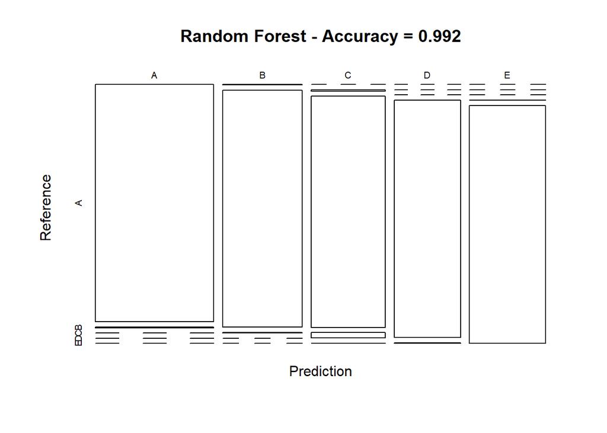

### Method 2 : Decision Trees

```
## Confusion Matrix and Statistics
##
##           Reference
## Prediction    A    B    C    D    E
##          A 1470  226   18  106   37
##          B   51  634   59   22   73
##          C   46  106  805  156  118
##          D   77   82   63  590   55
##          E   30   91   81   90  799
##
## Overall Statistics
##
##                Accuracy : 0.7303
##                  95% CI : (0.7188, 0.7416)
##     No Information Rate : 0.2845
##     P-Value [Acc > NIR] : < 2.2e-16
##
##                   Kappa : 0.6578
##
##  Mcnemar's Test P-Value : < 2.2e-16
##
## Statistics by Class:
##
##                      Class: A Class: B Class: C Class: D Class: E
## Sensitivity            0.8781   0.5566   0.7846   0.6120   0.7384
## Specificity            0.9081   0.9568   0.9123   0.9437   0.9392
## Pos Pred Value         0.7916   0.7557   0.6539   0.6805   0.7324
## Neg Pred Value         0.9494   0.8999   0.9525   0.9255   0.9410
## Prevalence             0.2845   0.1935   0.1743   0.1638   0.1839
## Detection Rate         0.2498   0.1077   0.1368   0.1003   0.1358
## Detection Prevalence   0.3155   0.1426   0.2092   0.1473   0.1854
## Balanced Accuracy      0.8931   0.7567   0.8485   0.7779   0.8388
```

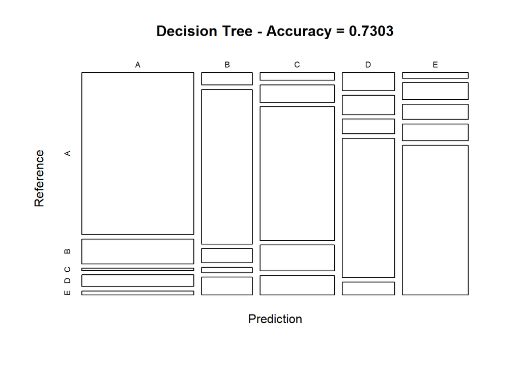

## Method 3 : Generalized Boosted Model

```
## Confusion Matrix and Statistics
##
##           Reference
## Prediction    A    B    C    D    E
##          A 1640   37    0    3    4
##          B   23 1073   28    2   10
##          C    5   27  982   41    6
##          D    6    1   16  910   18
##          E    0    1    0    8 1044
##
## Overall Statistics
##
##                Accuracy : 0.9599
##                  95% CI : (0.9546, 0.9648)
##     No Information Rate : 0.2845
##     P-Value [Acc > NIR] : < 2.2e-16
##
##                   Kappa : 0.9493
##
##  Mcnemar's Test P-Value : 8.162e-06
##
## Statistics by Class:
##
##                      Class: A Class: B Class: C Class: D Class: E
## Sensitivity            0.9797   0.9421   0.9571   0.9440   0.9649
## Specificity            0.9896   0.9867   0.9837   0.9917   0.9981
## Pos Pred Value         0.9739   0.9445   0.9255   0.9569   0.9915
## Neg Pred Value         0.9919   0.9861   0.9909   0.9891   0.9921
## Prevalence             0.2845   0.1935   0.1743   0.1638   0.1839
## Detection Rate         0.2787   0.1823   0.1669   0.1546   0.1774
## Detection Prevalence   0.2862   0.1930   0.1803   0.1616   0.1789
## Balanced Accuracy      0.9846   0.9644   0.9704   0.9678   0.9815
```

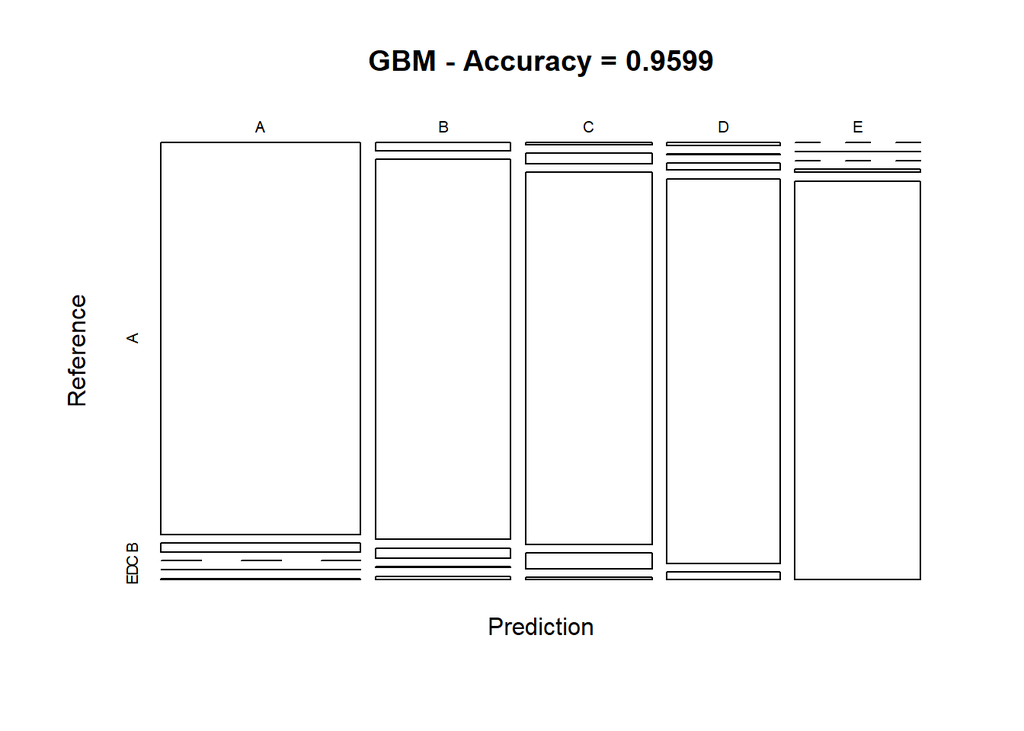

## Comparing results

Use the best Model to predict/validate the Test Data

The accuracy of the 3 regression modeling methods used above are:

- Random Forest : 0.992
- Decision Tree : 0.7303
- GBM : 0.9599  
  The Random Forest model scores best and will be used to predict the 20 quiz results on testing dataset as shown below.

```r
quizPrediction <- predict(modFitRF, newdata=testing)
quizPrediction
```

```
##  [1] B A B A A E D B A A B C B A E E A B B B
## Levels: A B C D E
```